# Exploring the 431 Class Survey

Patrick Wu

2020-12-08

# 1 Setup and Data Ingest

This study analyzes data from 147 students in PQHS 431 collected in 2019 and 2020. Various variables are analyzed, with a focus on gender as a predictor for various outcomes.

## 1.1 R Setup

These code chunks load necessary R libraries and set various options in R.

```r
knitr::opts_chunk$set(comment=NA)
options(width = 70)
```

```r
library(readr)
library(readxl)
library(Epi)
library(vcd)
library(broom)
library(knitr)
library(magrittr)
library(janitor)
library(tidyverse)

source("Love-boost.R")

theme_set(theme_bw())
```

## 1.2 Data Ingest

The first step is to ingest the data into R. There are two csv files containing data from 2020 and one Excel file containing data from 2019.

```r
sur2019 <- read_excel("data/431_projectB_survey_data_2019.xlsx", na = c("", "NA")) %>% clean_names()

sur2020a <- read_csv("data/431_projectB_survey_data_2020a.csv") %>% clean_names()

sur2020b <- read_csv("data/431_projectB_survey_data_2020b.csv") %>% clean_names()
```

# 2 Merging the Data

The next step is merging the data. This is straightforward as the 2020 files contain information on the same subjects and can be combined horizontally. Then, the 2019 and 2020 data sets can be combined vertically as they contain the same survey items.

```r
sur2020 <- inner_join(sur2020a, sur2020b, by = "subject_id")

sur <- bind_rows(sur2019, sur2020)
```

# 3 Cleaning the Data

The next step is cleaning the data. The variables needed for the analyses are selected, renamed, and changed to factors if categorical.

```r
sur_cleaned <- sur %>%
  select(main_03, main_04, main_06, main_16, main_13, main_01, main_36) %>%
  rename(female = main_03, glasses = main_04, married = main_06, groceries = main_16, pulse = main_13, born = main_01, season = main_36) %>%
  mutate(female = fct_relevel(female, "Yes"), glasses = fct_relevel(glasses, "Yes"), married = fct_relevel(married, "Yes"), groceries = fct_relevel(groceries, "Yes"), born = fct_relevel(born, "Yes"), season = fct_relevel(season, "Spring", "Summer", "Fall", "Winter"))

dim(sur_cleaned)
```

```
[1] 147   7
```

The dimensions of the data frame are correct, indicating that everything executed as expected.

## 3.1 Codebook

| Variable Name | Type | Original Name | Description |
| --- | --- | --- | --- |
| `female` | 2-Category | `Main-03` | Do you identify as female? (Yes or No) |
| `glasses` | 2-Category | `Main-04` | Do you wear prescription glasses or contact lenses? (Yes or No) |
| `married` | 2-Category | `Main-06` | Are you currently married or in a stable domestic relationship? (Yes or No, 1 missing value) |
| `groceries` | 2-Category | `Main-16` | In the past month, did you buy most of the groceries you consumed? (Yes or No) |
| `pulse` | Quantitative | `Main-13` | What is your pulse rate, in beats per minute? |
| `born` | 2-Category | `Main-01` | Were you born in the United States? (Yes or No) |
| `season` | 4-Category | `Main-36` | Which is your favorite season? (Spring, Summer, Fall, or Winter) |

# 4 Analysis B: Comparing Two Population Means Using Independent Samples

## 4.1 The Question

The purpose of this analysis is to examine potential differences in health between those who buy their own groceries and those who do not. The rationale for such an analysis is that people who buy their own groceries might be more health-conscious or more likely to make healthy choices. Thus, a health-related outcome variable, pulse rate, was chosen for this analysis. I would predict that students who do not buy their own groceries would have a higher average pulse rate. Therefore, the research question for this analysis is as follows:

Do students who primarily buy their own groceries have a meaningfully different pulse rate from those who do not?

## 4.2 Describing the Data

The categories being compared in this analysis are students who stated that they bought most of their own groceries in the past month and those who stated that they did not. The outcome variable is the students’ self-reported pulse rate, measured in beats per minute.

```r
mosaic::favstats(pulse ~ groceries, data = sur_cleaned) %>% kable(digits = 2)
```

| groceries | min | Q1 | median | Q3 | max | mean | sd | n | missing |
| --- | --- | --- | --- | --- | --- | --- | --- | --- | --- |
| Yes | 45 | 66 | 72 | 80 | 104 | 72.63 | 10.70 | 123 | 0 |
| No | 51 | 60 | 72 | 76 | 113 | 70.67 | 13.73 | 24 | 0 |

Most of the summary statistics for the two groups look fairly similar, with the No group having a somewhat lower mean and higher standard deviation. The No group also has a much smaller sample size.

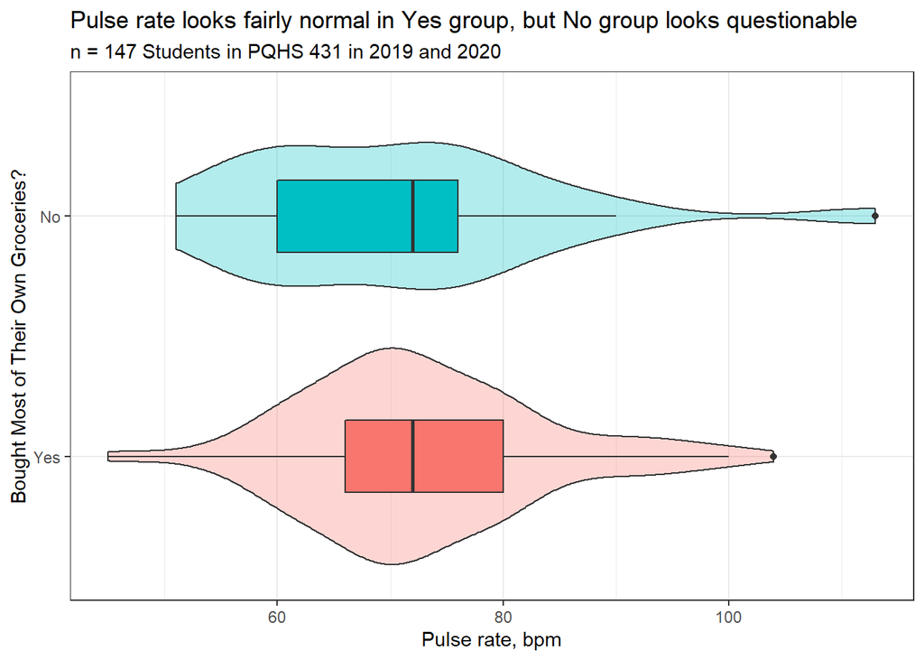

```r
ggplot(sur_cleaned, aes(x = pulse, y = groceries, fill = groceries)) +
  geom_violin(alpha = 0.3) +
  geom_boxplot(width = 0.3) +
  guides(fill = FALSE) +
  labs(title = "Pulse rate looks fairly normal in Yes group, but No group looks questionable",
       subtitle = "n = 147 Students in PQHS 431 in 2019 and 2020",
       x = "Pulse rate, bpm", y = "Bought Most of Their Own Groceries?")
```

The distribution of pulse rates for the Yes group looks fairly normal, but the normality of the No group looks more uncertain. The distribution seems heavy-tailed but it is unclear whether or not that is due to the extreme outlier on the high end of the distribution.

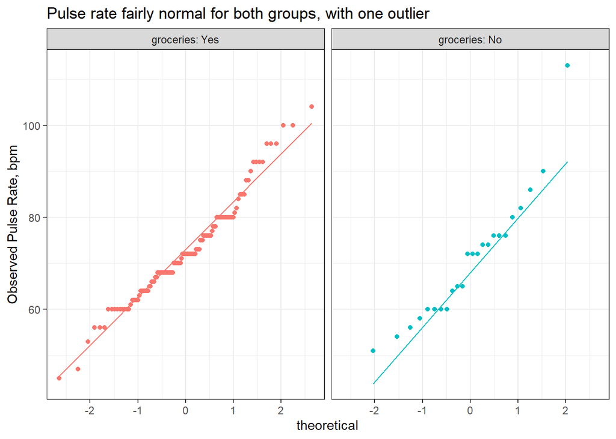

```r
ggplot(sur_cleaned, aes(sample = pulse, col = groceries)) +
  geom_qq() + geom_qq_line() +
  facet_wrap(~ groceries, labeller = "label_both") +
  guides(col = FALSE) +
  labs(y = "Observed Pulse Rate, bpm",
       title = "Pulse rate fairly normal for both groups, with one outlier")
```

```r
sur_cleaned %>% group_by(groceries) %>%
  summarize(skew1 = round((mean(pulse) - median(pulse))/sd(pulse), 3))
```

```
# A tibble: 2 x 2
  groceries  skew1
  <fct>      <dbl>
1 Yes        0.059
2 No        -0.097
```

The Normal Q-Q plots for each group show a fairly normal distribution, with one outlier in the No group. In addition, the skew<sub>1</sub> statistic does not show evidence of meaningful skew. Therefore, assuming normality seems reasonable for this analysis.

## 4.3 Main Analysis

```r
sur_cleaned %>% group_by(groceries) %>%
  summarize(n = n(), mean = mean(pulse), variance = var(pulse))
```

```
# A tibble: 2 x 4
  groceries     n  mean variance
  <fct>     <int> <dbl>    <dbl>
1 Yes         123  72.6     114.
2 No           24  70.7     188.
```

As there is a fair amount of difference in variance between the two groups and very unbalanced sample sizes, Welch’s t-test seems like the best analytical method. This analysis assumes that the samples in each group are drawn independently of each other, that the samples are drawn randomly from the populations of interest, and that the populations are normally distributed with regard to the outcome variable of interest.

```r
t.test(pulse ~ groceries, data = sur_cleaned, conf.level = 0.90) %>%
  tidy() %>%
  select(estimate, conf.low, conf.high)
```

```
# A tibble: 1 x 3
  estimate conf.low conf.high
     <dbl>    <dbl>     <dbl>
1     1.97    -3.07      7.00
```

## 4.4 Conclusions

The point estimate for the difference in pulse rate between students who primarily buy their own groceries and students who do not is 1.97 beats per minute, with a 90% confidence interval of -3.07 to 7.00. Therefore, there is no statistically detectable difference at a 10% significance level between the mean pulse rate of students who buy their own groceries and students who do not, based on this sample. One potential issue with this analysis is the extreme outlier in the No group. When the outlier is removed, the 90% confidence interval still contains 0. However, the point estimate of the difference between the groups, the mean of the No group, and the standard deviation of the No group all change substantially.

```r
sur_cleaned_test <- sur_cleaned %>% filter(pulse < 110)

t.test(pulse ~ groceries, data = sur_cleaned_test, conf.level = 0.90) %>%
  tidy() %>%
  select(estimate, conf.low, conf.high)
```

```
# A tibble: 1 x 3
  estimate conf.low conf.high
     <dbl>    <dbl>     <dbl>
1     3.81   -0.275      7.89
```

```r
mosaic::favstats(pulse ~ groceries, data = sur_cleaned_test) %>% kable(digits = 2)
```

| groceries | min | Q1 | median | Q3 | max | mean | sd | n | missing |
| --- | --- | --- | --- | --- | --- | --- | --- | --- | --- |
| Yes | 45 | 66 | 72 | 80 | 104 | 72.63 | 10.70 | 123 | 0 |
| No | 51 | 60 | 72 | 76 | 90 | 68.83 | 10.58 | 23 | 0 |

Notably, the standard deviations of the two groups now look much more similar. A logical next step might be to repeat this analysis with a larger sample of people who do not buy their own groceries, which would give a better idea of how representative a pulse rate of 113 bpm is for that group. In addition, as the results of this analysis were the opposite of what I predicted, with the Yes group having a higher average pulse rate and no significant difference between groups, it would be interesting to compare the two groups on other measures of health as well.

# 5 Analysis D: 2 x 2 Table

## 5.1 The Question

I have worn glasses since I was 6 years old, so eye health is a topic that has always been of interest to me. The research question for this analysis is as follows:

Do females have a detectably different likelihood of using glasses or contacts compared to non-females?

## 5.2 Describing the Data

The variables for this analysis are self-reported female identification and use of prescription glasses or contact lenses.

```r
sur_D <- sur_cleaned %>%
  select(female, glasses) %>%
  mutate(female = fct_recode(factor(female),
                                "Not Female" = "No",
                                "Female" = "Yes"),
         glasses = fct_recode(factor(glasses),
                                 "No Corrective Lenses" = "No",
                                 "Corrective Lenses" = "Yes"))

table(sur_D$female, sur_D$glasses)
```

```
             Corrective Lenses No Corrective Lenses
  Female                    62                   22
  Not Female                44                   19
```

## 5.3 Main Analysis

```r
tabD <- table(sur_D$female, sur_D$glasses)

twoby2(tabD + 2, conf.level = 0.90)
```

```
2 by 2 table analysis:
------------------------------------------------------
Outcome   : Corrective Lenses
Comparing : Female vs. Not Female

           Corrective Lenses No Corrective Lenses
Female                    64                   24
Not Female                46                   21
              P(Corrective Lenses) 90% conf. interval
Female                      0.7273    0.6427   0.7981
Not Female                  0.6866    0.5868   0.7716

                                   90% conf. interval
             Relative Risk: 1.0593    0.8909   1.2595
         Sample Odds Ratio: 1.2174    0.6780   2.1860
Conditional MLE Odds Ratio: 1.2158    0.6373   2.3144
    Probability difference: 0.0407   -0.0784   0.1621

             Exact P-value: 0.5966
        Asymptotic P-value: 0.5804
------------------------------------------------------
```

Each cell of the table has a value well over 10, so the chi-square test is appropriate here.

The probability of using corrective lenses for females in this sample was 73%, with a 90% confidence interval of 64% to 80%. The probability of using corrective lenses for non-females was 69%, with a 90% confidence interval of 59% to 77%.

The relative risk of wearing corrective lenses for females vs. non-females was estimated to be 1.06. The odds ratio of corrective lens use for females vs. non-females was estimated to be 1.22. Neither of these were detectably different from 1 at a 10% significance level. The difference in probability of corrective lens use for females vs. non-females was estimated to be 0.04, and was not detectably different from 0 at a 10% significance level. The p-values for both Fisher’s exact test and the Pearson chi-square test were well over 0.1.

## 5.4 Conclusions

No detectable difference was found in the likelihood of corrective lens use for females vs. non-females. Given that, this does not seem like a particularly interesting area for further research. Other, more interesting, topics relating to corrective lens use include the change in rates of usage over time and discrepancies in use between different racial groups.

# 6 Analysis E: 2 x 4 Table

## 6.1 The Question

For this analysis I was interested in whether gender had an influence on one’s favorite season. The research question is as follows:

Is there a statistically detectable difference between the favorite seasons of females and non-females?

## 6.2 Describing the Data

The variables for this analysis are self-reported female identification and favorite season.

```r
sur_E <- sur_cleaned %>%
  select(female, season) %>%
  mutate(female = fct_recode(factor(female),
                                "Not Female" = "No",
                                "Female" = "Yes"))

table(sur_E$female, sur_E$season)
```

```
             Spring Summer Fall Winter
  Female         18     20   41      5
  Not Female     14     17   24      8
```

## 6.3 Main Analysis

There are no cells with a count of 0 and 7 of the 8 cells have counts greater than 5, so the Cochran conditions are met.

```r
tabE <- table(sur_E$female, sur_E$season)

chisq.test(tabE)
```

```
    Pearson's Chi-squared test

data:  tabE
X-squared = 2.9417, df = 3, p-value = 0.4007
```

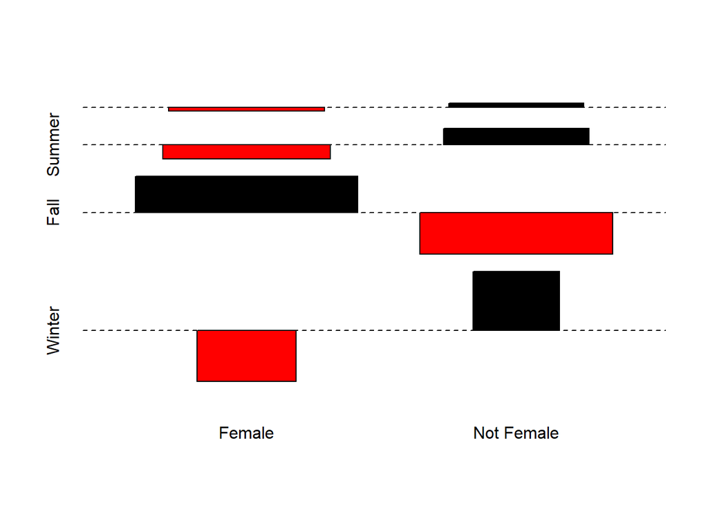

```r
assocplot(tabE)
```

## 6.4 Conclusions

With a p-value of 0.40, the Pearson chi-square test did not find a statistically significant association between gender and favorite season at the 10% significance level. Preference for fall and winter showed much more variation between females and non-females than preference for spring and summer, with females more likely to prefer fall and non-females more likely to prefer winter. Thus, a potential next step would be to survey females and non-females about how much they like fall and winter specifically and compare the results.

# 7 Analysis F: 2 x 2 x 2 Table

## 7.1 The Question

For this analysis, I was interested in different factors that might show an association with someone being married or in a stable relationship. The research question is as follows:

Does the relationship between a student’s gender and relationship or marriage status differ based on whether they were born in the US?

## 7.2 Describing the Data

The variables for this analysis are self-reported female identification, self-reported marriage or stable relationship status, and self-reported place of birth (inside or outside the US). There is missing data on the marriage/relationship status question for one student. This student will be excluded and only complete cases will be analyzed.

```r
sur_F <- sur_cleaned %>%
    select(female, married, born) %>%
    filter(complete.cases(.)) %>%
    mutate(female = fct_recode(factor(female),
                                "Not Female" = "No",
                                "Female" = "Yes"),
         married = fct_recode(factor(married),
                                 "Not Married or Relationship" = "No",
                                 "Married or Relationship" = "Yes"),
         born = fct_recode(factor(born),
                           "Not Born in US" = "No",
                           "Born in US" = "Yes"))

sur_F %>% tabyl(female, married, born)
```

```
$`Born in US`
     female Married or Relationship Not Married or Relationship
     Female                      18                          38
 Not Female                      17                          21

$`Not Born in US`
     female Married or Relationship Not Married or Relationship
     Female                      11                          16
 Not Female                      12                          13
```

```r
table_F1 <- sur_F %$%
  table(female, married, born)

addmargins(table_F1)
```

```
, , born = Born in US

            married
female       Married or Relationship Not Married or Relationship Sum
  Female                          18                          38  56
  Not Female                      17                          21  38
  Sum                             35                          59  94

, , born = Not Born in US

            married
female       Married or Relationship Not Married or Relationship Sum
  Female                          11                          16  27
  Not Female                      12                          13  25
  Sum                             23                          29  52

, , born = Sum

            married
female       Married or Relationship Not Married or Relationship Sum
  Female                          29                          54  83
  Not Female                      29                          34  63
  Sum                             58                          88 146
```

```r
table_F2 <- sur_F %$%
  table(born, female, married)

ftable(table_F2)
```

```
                          married Married or Relationship Not Married or Relationship
born           female
Born in US     Female                                  18                          38
               Not Female                              17                          21
Not Born in US Female                                  11                          16
               Not Female                              12                          13
```

## 7.3 Main Analysis

Since this is a complete case analysis it is necessary to assume that the data are missing completely at random. Fortunately, the amount of missing data is quite small.

```r
woolf_test(table_F1)
```

```
    Woolf-test on Homogeneity of Odds Ratios (no 3-Way assoc.)

data:  table_F1
X-squared = 0.11595, df = 1, p-value = 0.7335
```

The Woolf test shows no evidence to reject the null hypothesis that the odds ratios comparing odds of being married or in a relationship for females vs. non-females are consistent across strata (i.e. between those born in the US and outside the US). In addition, counts in all cells are greater than 10. Therefore, it is reasonable to proceed with the Cochran-Mantel-Haenszel test.

```r
mantelhaen.test(table_F1, conf.level = .90)
```

```
    Mantel-Haenszel chi-squared test with continuity correction

data:  table_F1
Mantel-Haenszel X-squared = 1.2594, df = 1, p-value = 0.2618
alternative hypothesis: true common odds ratio is not equal to 1
90 percent confidence interval:
 0.3646314 1.1266187
sample estimates:
common odds ratio
        0.6409373
```

## 7.4 Conclusions

The point estimate for the population odds ratio comparing odds of being married or in a relationship for females vs. non-females is 0.64, with a 90% confidence interval of 0.36 to 1.13. Therefore, at the 10% significance level there is no statistically detectable association between gender and marriage or relationship status after accounting for whether or not someone is born in the US. A possible next step for this research question might be to separate those who are married from those in a relationship or to examine multiple specific countries of origin with a larger sample size.